# Project: Investigate a Dataset - [No-show appointments]

- Introduction
- Data Wrangling
- Exploratory Data Analysis
- Conclusions

## Introduction

> This dataset comprises of information collected from more than 100,000 medical appointments in Brazil. It has 13 independents variables and one dependent variable (i.e., showing whether a patient show up for an appointment or not).

> A brief description of the 14 columns is provided below:
1. Pateint ID - This is a personal identifier for each patient.
2. Appointment ID - This is a seven-digit number for identifying each appointment.
3. Gender- This refers to the sex of the patient.
4. Schedule Day - This is the day the patient book the appointment.
5. Appointment Day - This is the day of appointment (the patient is expected to visit the hospital on this day).
6. Age - The age of the patient.
7. Neighborhood - This describes the location of the hospital.
8. Scholarship - This shows whether the patient is enjoying a scholarship benefit from Brasilian welfare program or not.
9. Hipertension - This shows whether the patient is hypertensive or not.
10. Diabetes - This indicates whether the patient has diabetics or not.
11. Alcoholism - This shows whether the patient take alcohol or not.
12. Handcap - This describes if a patient has a disability or not.
13. SMS_received - This indicates whether the patient receive an SMS or not after booking the appointment.
14. No-show - This is the dependable variable and it indicates whether a patient show up for the appointment or not. "No" means that the patient showed up, while "Yes" means that the patient do not show up.

Questions to be explored on the dataset (No show appointment):

1. What is the percentage of the appointments that were fulfilled?
2. Which gender is more likely to show up for appointment?
3. How is the age of the patients distributed based on their gender?
4. What is the relationship between being enrolled in a Brasilian welfare program (scholarship) and showing up for appointment?
5. Who showed up more for appointment between hypertensive and diabetic patients?
6. Is sending an SMS to the patient prior to the appointment day effective?
7. Which neighbourhood is most preffered for patients in terms of appointment?
8. What's the relationship between age and showing up for appointment?
9. Is there a relationship between age of patient and not showing up for appointment?

```python
# Import the relevant libraries
import pandas as pd
import numpy as np
import matplotlib.pyplot as plt
import seaborn as sns
%matplotlib inline
```

## Data Wrangling

### General Properties

```python
#loading the dataset
df = pd.read_csv('noshowappointments.csv')
df.head()
```

|  | PatientId | AppointmentID | Gender | ScheduledDay | AppointmentDay | Age | Neighbourhood | Scholarship | Hipertension | Diabetes | Alcoholism | Handcap | SMS_received | No-show |
| --- | --- | --- | --- | --- | --- | --- | --- | --- | --- | --- | --- | --- | --- | --- |
| 0 | 2.987250e+13 | 5642903 | F | 2016-04-29T18:38:08Z | 2016-04-29T00:00:00Z | 62 | JARDIM DA PENHA | 0 | 1 | 0 | 0 | 0 | 0 | No |
| 1 | 5.589978e+14 | 5642503 | M | 2016-04-29T16:08:27Z | 2016-04-29T00:00:00Z | 56 | JARDIM DA PENHA | 0 | 0 | 0 | 0 | 0 | 0 | No |
| 2 | 4.262962e+12 | 5642549 | F | 2016-04-29T16:19:04Z | 2016-04-29T00:00:00Z | 62 | MATA DA PRAIA | 0 | 0 | 0 | 0 | 0 | 0 | No |
| 3 | 8.679512e+11 | 5642828 | F | 2016-04-29T17:29:31Z | 2016-04-29T00:00:00Z | 8 | PONTAL DE CAMBURI | 0 | 0 | 0 | 0 | 0 | 0 | No |
| 4 | 8.841186e+12 | 5642494 | F | 2016-04-29T16:07:23Z | 2016-04-29T00:00:00Z | 56 | JARDIM DA PENHA | 0 | 1 | 1 | 0 | 0 | 0 | No |

```python
#checking the data shape
df.shape
```

```
(110527, 14)
```

This shows that the data consists of 110527 medical appointments and 14 variables incuding the dependent variable.

```python
#checking the datatypes
df.dtypes
```

```
PatientId         float64
AppointmentID       int64
Gender             object
ScheduledDay       object
AppointmentDay     object
Age                 int64
Neighbourhood      object
Scholarship         int64
Hipertension        int64
Diabetes            int64
Alcoholism          int64
Handcap             int64
SMS_received        int64
No-show            object
dtype: object
```

The datatypes are correct and need no changes as they are already appropriate for each data varaible.

```python
#checking if any of the variable has null values
df.isnull().sum()
```

```
PatientId         0
AppointmentID     0
Gender            0
ScheduledDay      0
AppointmentDay    0
Age               0
Neighbourhood     0
Scholarship       0
Hipertension      0
Diabetes          0
Alcoholism        0
Handcap           0
SMS_received      0
No-show           0
dtype: int64
```

This shows that there is no missing values in the dataset. Hence, there is no need to drop or modify the rows.

```python
df.nunique()
```

```
PatientId          62299
AppointmentID     110527
Gender                 2
ScheduledDay      103549
AppointmentDay        27
Age                  104
Neighbourhood         81
Scholarship            2
Hipertension           2
Diabetes               2
Alcoholism             2
Handcap                5
SMS_received           2
No-show                2
dtype: int64
```

This shows that only 62299 patients made the 110527 appointments.

```python
df['PatientId'].value_counts()
```

```
8.221459e+14    88
9.963767e+10    84
2.688613e+13    70
3.353478e+13    65
6.264199e+12    62
                ..
8.622636e+11     1
9.267587e+12     1
5.764356e+12     1
5.712491e+12     1
1.557663e+13     1
Name: PatientId, Length: 62299, dtype: int64
```

```python
#confirming the number of non-null numbers for all the variables
df.info()
```

```
<class 'pandas.core.frame.DataFrame'>
RangeIndex: 110527 entries, 0 to 110526
Data columns (total 14 columns):
 #   Column          Non-Null Count   Dtype
---  ------          --------------   -----
 0   PatientId       110527 non-null  float64
 1   AppointmentID   110527 non-null  int64
 2   Gender          110527 non-null  object
 3   ScheduledDay    110527 non-null  object
 4   AppointmentDay  110527 non-null  object
 5   Age             110527 non-null  int64
 6   Neighbourhood   110527 non-null  object
 7   Scholarship     110527 non-null  int64
 8   Hipertension    110527 non-null  int64
 9   Diabetes        110527 non-null  int64
 10  Alcoholism      110527 non-null  int64
 11  Handcap         110527 non-null  int64
 12  SMS_received    110527 non-null  int64
 13  No-show         110527 non-null  object
dtypes: float64(1), int64(8), object(5)
memory usage: 11.8+ MB
```

```python
#checking for duplicates in the datasets
sum(df.duplicated())
```

```
0
```

This shows that there are no duplicates in the dataset

```python
#checking the range of values in the age column
df['Age'].value_counts()
```

```
 0      3539
 1      2273
 52     1746
 49     1652
 53     1651
        ...
 115       5
 100       4
 102       2
 99        1
-1         1
Name: Age, Length: 104, dtype: int64
```

This result shows that a cell contain age to be -1, which is not realistic. Therefore, this cell would be dropped.

### Data Cleaning (Dropping irrelevant variables, row and creating a new dataframe)

```python
#checking the irrelevant row in Age column
irr_age = df.query('Age == -1')
irr_age
```

|  | PatientId | AppointmentID | Gender | ScheduledDay | AppointmentDay | Age | Neighbourhood | Scholarship | Hipertension | Diabetes | Alcoholism | Handcap | SMS_received | No-show |
| --- | --- | --- | --- | --- | --- | --- | --- | --- | --- | --- | --- | --- | --- | --- |
| 99832 | 4.659432e+14 | 5775010 | F | 2016-06-06T08:58:13Z | 2016-06-06T00:00:00Z | -1 | ROMÃO | 0 | 0 | 0 | 0 | 0 | 0 | No |

```python
#dropping the irrelevant row in Age column
df.drop(99832, axis=0, inplace = True)
#confirming the dropping
df['Age'].value_counts()
```

```
0      3539
1      2273
52     1746
49     1652
53     1651
       ...
98        6
115       5
100       4
102       2
99        1
Name: Age, Length: 103, dtype: int64
```

There are 62299 patients in the database who made 110527 appointments. This means some of them made more than one appointment. So, I created a new database that contains only 62299 data points (rows) to investigate the trends in the two databases (original and new database) to see if there would be some differences in the trends over time.

```python
#checking the array of the unique patients
uniquepatients = df['PatientId'].unique()
uniquepatients
```

```
array([2.98724998e+13, 5.58997777e+14, 4.26296230e+12, ...,
       7.26331493e+13, 9.96997666e+14, 1.55766317e+13])
```

```python
#creating the new dataset (unique patients dataset)
df_up = df.drop_duplicates(subset = ['PatientId'])
df_up.shape
```

```
(62298, 14)
```

```python
#looking up some random rows in the new created dataframe to affirm its correctness
df_up.sample(10)
```

|  | PatientId | AppointmentID | Gender | ScheduledDay | AppointmentDay | Age | Neighbourhood | Scholarship | Hipertension | Diabetes | Alcoholism | Handcap | SMS_received | No-show |
| --- | --- | --- | --- | --- | --- | --- | --- | --- | --- | --- | --- | --- | --- | --- |
| 25874 | 9.839182e+09 | 5644454 | F | 2016-05-02T08:42:01Z | 2016-05-16T00:00:00Z | 78 | ESTRELINHA | 0 | 1 | 1 | 0 | 0 | 0 | Yes |
| 45300 | 9.918527e+11 | 5621785 | F | 2016-04-26T10:48:46Z | 2016-05-11T00:00:00Z | 19 | SANTO ANTÔNIO | 0 | 0 | 0 | 0 | 0 | 1 | No |
| 60914 | 4.596918e+13 | 5688742 | F | 2016-05-12T07:37:13Z | 2016-05-16T00:00:00Z | 60 | SÃO PEDRO | 0 | 1 | 0 | 0 | 0 | 0 | No |
| 73154 | 9.538115e+11 | 5662289 | F | 2016-05-05T08:21:03Z | 2016-05-18T00:00:00Z | 47 | SANTA LUÍZA | 0 | 0 | 0 | 0 | 0 | 0 | No |
| 19141 | 9.461573e+10 | 5715893 | F | 2016-05-18T15:22:21Z | 2016-05-18T00:00:00Z | 5 | JARDIM CAMBURI | 0 | 0 | 0 | 0 | 0 | 0 | No |
| 66448 | 9.779663e+14 | 5693807 | M | 2016-05-13T07:42:04Z | 2016-05-13T00:00:00Z | 9 | SANTA MARTHA | 1 | 0 | 0 | 0 | 0 | 0 | No |
| 39455 | 9.742148e+12 | 5642136 | F | 2016-04-29T15:08:31Z | 2016-05-03T00:00:00Z | 59 | CONQUISTA | 0 | 0 | 0 | 0 | 0 | 1 | No |
| 71896 | 4.621186e+14 | 5628694 | F | 2016-04-27T11:26:53Z | 2016-05-11T00:00:00Z | 50 | REPÚBLICA | 0 | 0 | 0 | 0 | 0 | 1 | No |
| 3700 | 4.583520e+12 | 5538722 | M | 2016-04-01T13:19:39Z | 2016-05-05T00:00:00Z | 49 | RESISTÊNCIA | 0 | 0 | 0 | 0 | 0 | 1 | Yes |
| 12031 | 6.549983e+12 | 5719940 | M | 2016-05-19T12:48:56Z | 2016-05-19T00:00:00Z | 0 | MONTE BELO | 0 | 0 | 0 | 0 | 0 | 0 | No |

```python
#confirming the uniqueness of PatientId in the unique patients dataset
df_up.nunique()
```

```
PatientId         62298
AppointmentID     62298
Gender                2
ScheduledDay      60508
AppointmentDay       27
Age                 103
Neighbourhood        81
Scholarship           2
Hipertension          2
Diabetes              2
Alcoholism            2
Handcap               5
SMS_received          2
No-show               2
dtype: int64
```

PatientId and AppointmentID are only identifiers and are not important for predicting the dependent variable. Hence, they are removed from the dataset.

```python
#rename column "No-show" to "No_show" to avoild computatinal error
df.rename(columns ={'No-show' : 'No_show'}, inplace = True)
df_up.rename(columns ={'No-show' : 'No_show'}, inplace = True)
df.head(1)
```

|  | PatientId | AppointmentID | Gender | ScheduledDay | AppointmentDay | Age | Neighbourhood | Scholarship | Hipertension | Diabetes | Alcoholism | Handcap | SMS_received | No_show |
| --- | --- | --- | --- | --- | --- | --- | --- | --- | --- | --- | --- | --- | --- | --- |
| 0 | 2.987250e+13 | 5642903 | F | 2016-04-29T18:38:08Z | 2016-04-29T00:00:00Z | 62 | JARDIM DA PENHA | 0 | 1 | 0 | 0 | 0 | 0 | No |

```python
#droping the two columns from the dataset
df.drop(['PatientId', 'AppointmentID'], axis=1, inplace=True)
df.head(1)
```

|  | Gender | ScheduledDay | AppointmentDay | Age | Neighbourhood | Scholarship | Hipertension | Diabetes | Alcoholism | Handcap | SMS_received | No_show |
| --- | --- | --- | --- | --- | --- | --- | --- | --- | --- | --- | --- | --- |
| 0 | F | 2016-04-29T18:38:08Z | 2016-04-29T00:00:00Z | 62 | JARDIM DA PENHA | 0 | 1 | 0 | 0 | 0 | 0 | No |

```python
#droping the two columns from the unique patients dataset
df_up.drop(['PatientId', 'AppointmentID'], axis=1, inplace=True)
df_up.head(1)
```

|  | Gender | ScheduledDay | AppointmentDay | Age | Neighbourhood | Scholarship | Hipertension | Diabetes | Alcoholism | Handcap | SMS_received | No_show |
| --- | --- | --- | --- | --- | --- | --- | --- | --- | --- | --- | --- | --- |
| 0 | F | 2016-04-29T18:38:08Z | 2016-04-29T00:00:00Z | 62 | JARDIM DA PENHA | 0 | 1 | 0 | 0 | 0 | 0 | No |

## Exploratory Data Analysis

# 1. What is the percentage of the appointments that were fulfilled?

```python
#creating a dataset consiting of the appointments that were fulfilled
#and subsequently referred to as appointment dataset
dfappoint = df.query('No_show  == "No"')
app = dfappoint['No_show'].count()
app
```

```
88207
```

```python
#creating a dataset consiting of the appointments that were not fulfilled
#and subsequently referred to as no-appointment dataset
df_noappoint = df.query('No_show  == "Yes"')
no_app = df_noappoint['No_show'].count()
no_app
```

```
22319
```

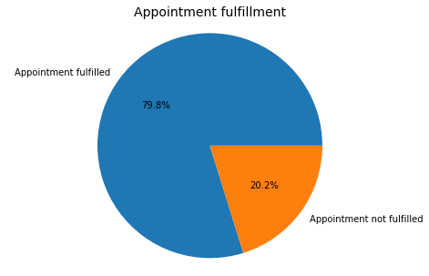

```python
#creating a pie chart to visualise the percentage of appintments that were fulfilled
#and the percentage of appointments that were not fulfilled

plt.subplots(figsize=(8, 5))
label = ['Appointment fulfilled', 'Appointment not fulfilled']
plt.pie([app, no_app ], labels = label, autopct='%1.1f%%')
plt.axis('equal')
plt.title('Appointment fulfillment', fontsize=14);
```

The result indicates that 20.2% of the appointments were not fulfilled.

# 2. Which gender is more likely to show up for appointment?

```python
#getting the total number of female in the original dataset
n_Female = df.query('Gender == "F"').Gender.count()
n_Female
```

```
71839
```

```python
#getting the number of male and female in the appointment dataset
dfappoint['Gender'].value_counts()
```

```
F    57245
M    30962
Name: Gender, dtype: int64
```

```python
#getting the number of male and female in the appointment dataset
dfappoint['Gender'].value_counts()
```

```
F    57245
M    30962
Name: Gender, dtype: int64
```

```python
#getting the number of female patients that fulfilled the appointments in the appointment dataset
Female = dfappoint.query('Gender == "F"').Gender.count()
Female
```

```
57245
```

```python
#getting the percentage of females that fulfilled the appointment
pFemale = (Female/n_Female)*100
pFemale
```

```
79.68512924734476
```

```python
#getting the total number of male in the original dataset
n_Male = df.query('Gender == "M"').Gender.count()
n_Male
```

```
38687
```

```python
#getting the number of male patients that fulfilled the appointments in the appointment dataset
Male = dfappoint.query('Gender == "M"').Gender.count()
Male
```

```
30962
```

```python
#getting the percentage of males that fulfilled the appointment
pMale = (Male/n_Male)*100
pMale
```

```
80.03205211052808
```

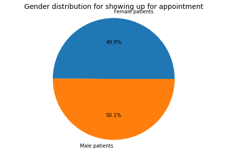

```python
#plotting the above result in a pie chart
plt.subplots(figsize=(8, 5))
label = ['Female patients', 'Male patients']
plt.pie([pFemale, pMale], labels = label, autopct='%1.1f%%')
plt.axis('equal')
plt.title('Gender distribution for showing up for appointment', fontsize=14);
```

```python
#getting the total number of female in the uniue patients dataset
n_Female_up = df_up.query('Gender == "F"').Gender.count()
n_Female_up
```

```
40045
```

```python
#creating a dataframe consiting of the appointments that were fulfilled from the unique patients dataset
#and subsequently referred to as unique patient appoint dataset
df_up_appoint = df_up.query('No_show  == "No"')
df_up_appoint.shape
```

```
(50105, 12)
```

```python
#getting the number of male and female in the unique patients appoint dataset
df_up_appoint['Gender'].value_counts()
```

```
F    32217
M    17888
Name: Gender, dtype: int64
```

```python
#getting the number of female patients that fulfilled the appointments in the unique patients appoint dataset
Female_up = df_up_appoint.query('Gender == "F"').Gender.count()
Female_up
```

```
32217
```

```python
#getting the percentage of females that fulfilled the appointment from the unique patients appoint dataset
pFemale_up = (Female_up/n_Female_up)*100
pFemale_up
```

```
80.45199150955176
```

```python
#getting the total number of male in the unique patients dataset
n_Male_up = df_up.query('Gender == "M"').Gender.count()
n_Male_up
```

```
22253
```

```python
#getting the number of male patients that fulfilled the appointments in the unique patients appoint dataset
Male_up = df_up_appoint.query('Gender == "M"').Gender.count()
Male_up
```

```
17888
```

```python
#getting the percentage of males that fulfilled the appointment
pMale_up = (Male_up/n_Male_up)*100
pMale_up
```

```
80.38466723587831
```

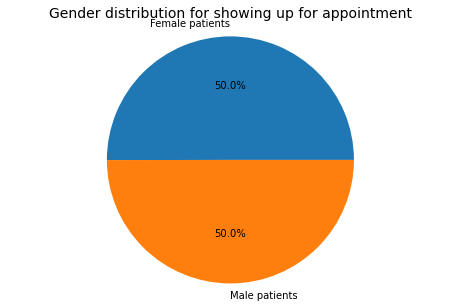

```python
#plotting the above result in a pie chart
plt.subplots(figsize=(8, 5))
label = ['Female patients', 'Male patients']
plt.pie([pFemale_up, pMale_up], labels = label, autopct='%1.1f%%')
plt.axis('equal')
plt.title('Gender distribution for showing up for appointment', fontsize=14);
```

This result follow the same trend as that of the appointment dataset, typfying that the choice of appointment fulfillment by the patients do not change with time.

# 3. How is the age of the patients distributed based on their gender?

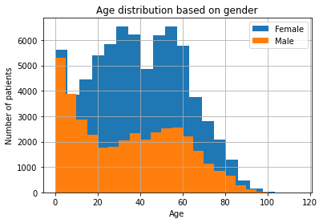

```python
Fe = df.Gender == 'F' #creating a mask for the female gender
Ma = df.Gender == 'M' #creating a mask for the male gender
df.Age[Fe].hist( bins=20, label = "Female")
df.Age[Ma].hist( bins=20, label = "Male")
plt.title('Age distribution based on gender')
plt.xlabel('Age')
plt.ylabel('Number of patients')
plt.legend();
```

```python
Fe.value_counts()
```

```
True     71839
False    38687
Name: Gender, dtype: int64
```

# 4. What is the relationship between being enrolled in a Brasilian welfare program (scholarship) and showing up for appointment?

```python
#getting the number of appointments with and without scholarship program for the appointment dataset
dfappoint['Scholarship'].value_counts()
```

```
0    79924
1     8283
Name: Scholarship, dtype: int64
```

```python
#getting the number of appointments made with an enrollment in the scholarship program from the appointment dataset
sch = dfappoint.query('Scholarship == 1').Scholarship.count()
sch
```

```
8283
```

```python
#getting the number of appointments made without an enrollment in the scholarship program from the appointment dataset
nosch = dfappoint.query('Scholarship == 0').Scholarship.count()
nosch
```

```
79924
```

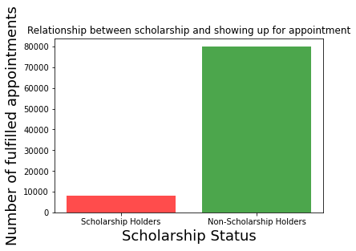

```python
#plotting a bar chart to demostrate the above results
colors = ['red', 'green']
plt.bar(['Scholarship Holders', 'Non-Scholarship Holders'], [sch, nosch], color=colors, alpha=0.7)
plt.title('Relationship between scholarship and showing up for appointment')
plt.xlabel('Scholarship Status', fontsize=18)
plt.ylabel ('Number of fulfilled appointments', fontsize=18);
```

```python
#getting the number of appointments made with an enrollment in the scholarship program
#from the unique patients appoint dataset
up_sch = df_up_appoint.query('Scholarship == 1').Scholarship.count()
up_sch
```

```
4481
```

```python
#getting the number of appointments made without an enrollment in the scholarship program
#from the unique patients appoint dataset
up_nosch = df_up_appoint.query('Scholarship == 0').Scholarship.count()
up_nosch
```

```
45624
```

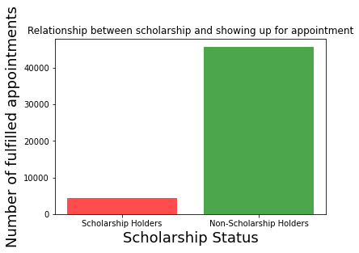

```python
#plotting a bar chart to demostrate the above results
colors = ['red', 'green']
plt.bar(['Scholarship Holders', 'Non-Scholarship Holders'], [up_sch, up_nosch], color=colors, alpha=0.7)
plt.title('Relationship between scholarship and showing up for appointment')
plt.xlabel('Scholarship Status', fontsize=18)
plt.ylabel ('Number of fulfilled appointments', fontsize=18);
```

```python
df.head()
```

|  | Gender | ScheduledDay | AppointmentDay | Age | Neighbourhood | Scholarship | Hipertension | Diabetes | Alcoholism | Handcap | SMS_received | No_show |
| --- | --- | --- | --- | --- | --- | --- | --- | --- | --- | --- | --- | --- |
| 0 | F | 2016-04-29T18:38:08Z | 2016-04-29T00:00:00Z | 62 | JARDIM DA PENHA | 0 | 1 | 0 | 0 | 0 | 0 | No |
| 1 | M | 2016-04-29T16:08:27Z | 2016-04-29T00:00:00Z | 56 | JARDIM DA PENHA | 0 | 0 | 0 | 0 | 0 | 0 | No |
| 2 | F | 2016-04-29T16:19:04Z | 2016-04-29T00:00:00Z | 62 | MATA DA PRAIA | 0 | 0 | 0 | 0 | 0 | 0 | No |
| 3 | F | 2016-04-29T17:29:31Z | 2016-04-29T00:00:00Z | 8 | PONTAL DE CAMBURI | 0 | 0 | 0 | 0 | 0 | 0 | No |
| 4 | F | 2016-04-29T16:07:23Z | 2016-04-29T00:00:00Z | 56 | JARDIM DA PENHA | 0 | 1 | 1 | 0 | 0 | 0 | No |

# 5. Who showed up more for appointment between hypertensive and diabetic patients?

```python
#creating a custom function to explore the relationship between the variables
#and showing up for appointment in the original dataset
def percent (column_name):
    feature_present = df.query(' {} == 1'.format(column_name))['No_show'].value_counts() #creating a dataframe that contains 1 for each of the feature
    percent_showup = feature_present['No'] / sum(feature_present)
    return (percent_showup*100)
```

```python
#establishing the relationship between hipertension and showing up for appointment
phip = percent('Hipertension')
phip
```

```
82.69804137424889
```

The result shows that despite the fact that the patients have hypertension, 82.69804137424889% still showed up for the appointments.

```python
#establishing the relationship between diabetes and showing up for appointment
pdia = percent('Diabetes')
pdia
```

```
81.99672667757774
```

The result shows that despite the fact that the patients have diabetes, 81.99672667757774% still showed up for the appointments.

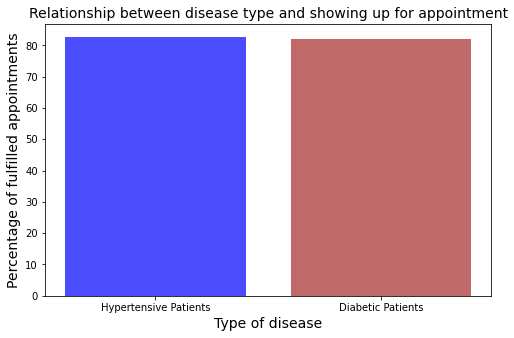

```python
#plotting a bar chart to demostrate the above results
plt.subplots(figsize=(8, 5))
colors = ['blue', 'brown']
plt.bar(['Hypertensive Patients', 'Diabetic Patients'], [phip, pdia], color=colors, alpha=0.7)
plt.title('Relationship between disease type and showing up for appointment', fontsize=14)
plt.xlabel('Type of disease', fontsize=14)
plt.ylabel ('Percentage of fulfilled appointments', fontsize=14);
```

The result shows that people with hypertension and diabetes have almost the same tendency to show up for appointment.

```python
#creating a custom function to explore the relationship between the variables
#and showing up for appointment in the unique patient dataset
def percent_up (column_name):
    feature_present_up = df_up.query(' {} == 1'.format(column_name))['No_show'].value_counts() #creating a dataframe that contains 1 for each of the feature
    percent_showup_up = feature_present_up['No'] / sum(feature_present_up)
    return (percent_showup_up*100)
```

```python
#establishing the relationship between hipertension and showing up for appointment in the unique patient dataset
phip_up = percent_up('Hipertension')
phip_up
```

```
83.50759679790883
```

The result shows that despite the fact that the patients have hypertension,83.50759679790883% still showed up for the appointments.

```python
#establishing the relationship between diabetes and showing up for appointment in the unique patient dataset
pdia_up = percent_up('Diabetes')
pdia_up
```

```
82.78985507246377
```

The result shows that despite the fact that the patients have diabetes, 82.78985507246377% still showed up for the appointments.

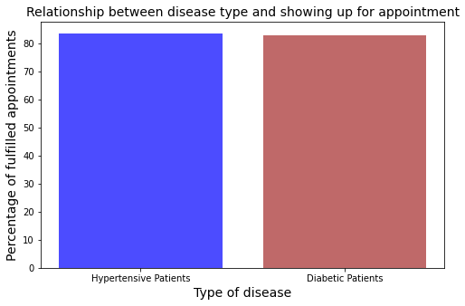

```python
#plotting a bar chart to demostrate the above results
plt.subplots(figsize=(8, 5))
colors = ['blue', 'brown']
plt.bar(['Hypertensive Patients', 'Diabetic Patients'], [phip_up, pdia_up], color=colors, alpha=0.7)
plt.title('Relationship between disease type and showing up for appointment', fontsize=14)
plt.xlabel('Type of disease', fontsize=14)
plt.ylabel ('Percentage of fulfilled appointments', fontsize=14);
```

# 6. Is sending an SMS to the patient prior to the appointment day effective?

```python
#creating a function for this purpose
def percent1 (column_name):
    feature_present = df.query(' {} == 1'.format(column_name))['No_show'].value_counts() #creating a dataframe that contains 1 for each of the feature
    percent_showup = feature_present['No'] / sum(feature_present)
    feature_notpresent = df.query(' {} == 0'.format(column_name))['No_show'].value_counts() #creating a dataframe that contains 0 for each of the feature
    percent_showup_nofeature = feature_notpresent['No'] / sum(feature_notpresent)
    return (percent_showup*100, percent_showup_nofeature*100)
```

```python
SMS = percent1('SMS_received')
SMS
```

```
(72.425455160363, 83.29646607323703)
```

This result indicates that 72.4% of the patients that recieved the SMS showed up for the appointment, whille 83.3% of the patients that do not received the appointments also showed up.

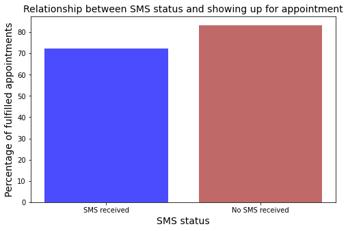

```python
#plotting a bar chart to demostrate the above results
plt.subplots(figsize=(8, 5))
colors = ['blue', 'brown']
plt.bar(['SMS received', 'No SMS received'], SMS, color=colors, alpha=0.7)
plt.title('Relationship between SMS status and showing up for appointment', fontsize=14)
plt.xlabel('SMS status', fontsize=14)
plt.ylabel ('Percentage of fulfilled appointments', fontsize=14);
```

```python
#checking the trend in the unique patient dataset
def percent1_up (column_name):
    feature_present_up = df_up.query(' {} == 1'.format(column_name))['No_show'].value_counts() #creating a dataframe that contains 1 for each of the feature
    percent_showup_up = feature_present_up['No'] / sum(feature_present_up)
    feature_notpresent_up = df_up.query(' {} == 0'.format(column_name))['No_show'].value_counts() #creating a dataframe that contains 0 for each of the feature
    percent_showup_nofeature_up = feature_notpresent_up['No'] / sum(feature_notpresent_up)
    return (percent_showup_up*100, percent_showup_nofeature_up*100)
```

```python
SMS_up = percent1_up('SMS_received')
SMS_up
```

```
(73.07541433755026, 84.00630011454754)
```

This result indicates that 73.1% of the patients that recieved the SMS showed up for the appointment, whille 84.0% of the patients that do not received the appointments also showed up.This follows the same trend as that of the original dataset.

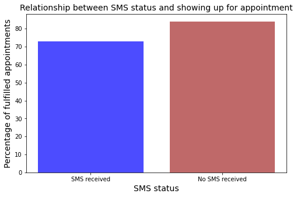

```python
#plotting a bar chart to demostrate the above results
plt.subplots(figsize=(8, 5))
colors = ['blue', 'brown']
plt.bar(['SMS received', 'No SMS received'], SMS_up, color=colors, alpha=0.7)
plt.title('Relationship between SMS status and showing up for appointment', fontsize=14)
plt.xlabel('SMS status', fontsize=14)
plt.ylabel ('Percentage of fulfilled appointments', fontsize=14);
```

# 7. Which neighbourhood is most preffered for patients in terms of appointment?

```python
#getting the number of appointments made at each neighbourhood  from the appointment dataset
neig = dfappoint['Neighbourhood'].value_counts()
neig
```

```
JARDIM CAMBURI       6252
MARIA ORTIZ          4586
RESISTÊNCIA          3525
JARDIM DA PENHA      3246
SANTA MARTHA         2635
                     ...
PONTAL DE CAMBURI      57
ILHA DO BOI            32
ILHA DO FRADE           8
AEROPORTO               7
PARQUE INDUSTRIAL       1
Name: Neighbourhood, Length: 80, dtype: int64
```

This indicates that JARDIM CAMBURI, MARIA ORTIZ, and RESISTÊNCIA are likely the top three preffered locations (i.e., hospitals) for appointent, while PARQUE INDUSTRIAL, AEROPORTO and ILHA DO FRADE appear to be the least preffered locations

```python
#selecting the top three preferred locations and finding their proportions
a = neig[:3]
b = dfappoint['Neighbourhood'].count()
for i in a:
    j = a/b
print (j)
```

```
JARDIM CAMBURI    0.070879
MARIA ORTIZ       0.051991
RESISTÊNCIA       0.039963
Name: Neighbourhood, dtype: float64
```

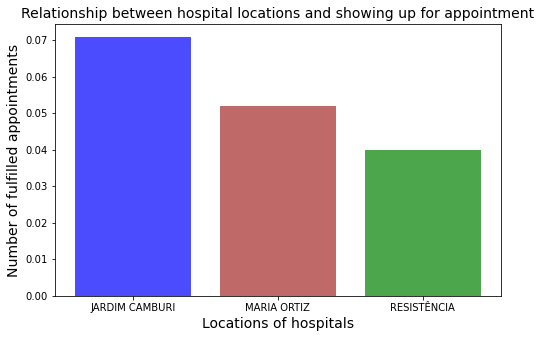

```python
#plotting the above results (the top three locations) on a bar chart
plt.subplots(figsize=(8, 5))
colors = ['blue', 'brown', 'green']
plt.bar(j.index, j, color=colors, alpha=0.7)
plt.title('Relationship between hospital locations and showing up for appointment', fontsize=14)
plt.xlabel('Locations of hospitals', fontsize=14)
plt.ylabel ('Number of fulfilled appointments', fontsize=14);
```

```python
#getting the number of appointments made at each neighbourhood from the unique patients appoint dataset
neig = df_up_appoint['Neighbourhood'].value_counts()
neig
```

```
JARDIM CAMBURI       3421
MARIA ORTIZ          2647
JARDIM DA PENHA      2010
RESISTÊNCIA          1904
ITARARÉ              1616
                     ...
PONTAL DE CAMBURI      38
ILHA DO BOI            21
AEROPORTO               6
ILHA DO FRADE           4
PARQUE INDUSTRIAL       1
Name: Neighbourhood, Length: 80, dtype: int64
```

This indicates that JARDIM CAMBURI, MARIA ORTIZ, and JARDIM DA PENHA are likely the top three preferred locations (i.e., hospitals) for appointent, while PARQUE INDUSTRIAL, ILHA DO FRADE and AEROPORTO appear to be the least preffered locations.

It is noticed that RESISTÊNCIA is the third preferred location in the appointment dataset, while JARDIM DA PENHA is the third preferred location in the unique patients appoint dataset. This may indicate that the pateints change their preferred location over time. The same trend was noticed for the third least preferred locations.

```python
#selecting the top three preferred locations and finding their proportions
a = neig[:3]
b = df_up_appoint['Neighbourhood'].count()
for i in a:
    j = a/b
print (j)
```

```
JARDIM CAMBURI     0.068277
MARIA ORTIZ        0.052829
JARDIM DA PENHA    0.040116
Name: Neighbourhood, dtype: float64
```

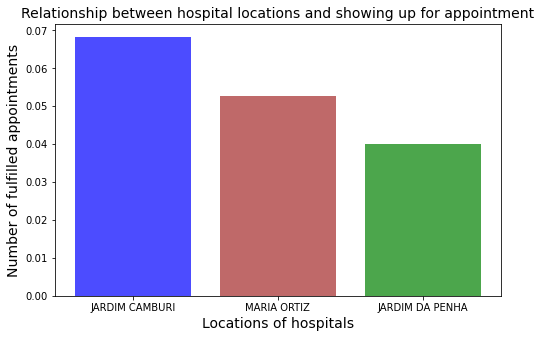

```python
#plotting the above results (the top three locations) on a bar chart
plt.subplots(figsize=(8, 5))
colors = ['blue', 'brown', 'green']
plt.bar(j.index, j, color=colors, alpha=0.7)
plt.title('Relationship between hospital locations and showing up for appointment', fontsize=14)
plt.xlabel('Locations of hospitals', fontsize=14)
plt.ylabel ('Number of fulfilled appointments', fontsize=14);
```

# 8. What's the relationship between age and showing up for appointment?

```python
dfappoint['Age'].value_counts()
```

```
0      2900
1      1858
52     1449
56     1372
2      1366
       ...
98        5
100       4
102       2
115       2
99        1
Name: Age, Length: 103, dtype: int64
```

There are 103 unique age in the dataset. Therefore, there is a need to group them them to few classes to establish the relationship between them and showing up for appointments.

```python
#viewing the min to max age distribution in the database
dfappoint['Age'].describe()
```

```
count    88207.000000
mean        37.790504
std         23.338645
min          0.000000
25%         18.000000
50%         38.000000
75%         56.000000
max        115.000000
Name: Age, dtype: float64
```

The age would be grouped into four classes based on the descriptive statistics shown above. Young: 0 - 18 years, Average: 18 - 38 years, Average-Old: 38 - 56 years and Old: 56 - 115 years

```python
#creating bin edges to cut the data into groups using the values gotten from the descriptive statistics
edges = [0, 18, 38, 56, 115]

#creating labels for the four groups
labelnames = ['Young', 'Average', 'Average_old', 'Old']
```

```python
#creating age group column
dfappoint['Age_group'] = pd.cut(dfappoint['Age'], edges, labels=labelnames)

#confirm the newly created column
dfappoint.head()
```

|  | Gender | ScheduledDay | AppointmentDay | Age | Neighbourhood | Scholarship | Hipertension | Diabetes | Alcoholism | Handcap | SMS_received | No_show | Age_group |
| --- | --- | --- | --- | --- | --- | --- | --- | --- | --- | --- | --- | --- | --- |
| 0 | F | 2016-04-29T18:38:08Z | 2016-04-29T00:00:00Z | 62 | JARDIM DA PENHA | 0 | 1 | 0 | 0 | 0 | 0 | No | Old |
| 1 | M | 2016-04-29T16:08:27Z | 2016-04-29T00:00:00Z | 56 | JARDIM DA PENHA | 0 | 0 | 0 | 0 | 0 | 0 | No | Average_old |
| 2 | F | 2016-04-29T16:19:04Z | 2016-04-29T00:00:00Z | 62 | MATA DA PRAIA | 0 | 0 | 0 | 0 | 0 | 0 | No | Old |
| 3 | F | 2016-04-29T17:29:31Z | 2016-04-29T00:00:00Z | 8 | PONTAL DE CAMBURI | 0 | 0 | 0 | 0 | 0 | 0 | No | Young |
| 4 | F | 2016-04-29T16:07:23Z | 2016-04-29T00:00:00Z | 56 | JARDIM DA PENHA | 0 | 1 | 1 | 0 | 0 | 0 | No | Average_old |

```python
#getting the number of appointments associated with each age group
groupage = dfappoint.groupby(['Age_group'], as_index=True)['No_show'].count()
groupage
```

```
Age_group
Young          19619
Average        22145
Average_old    21714
Old            21829
Name: No_show, dtype: int64
```

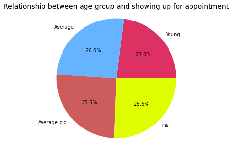

```python
#plotting the result in a pie chart to visualise the age distribution with respect to showing up for appointment
plt.subplots(figsize=(8, 5))
color = ['#DE3163','#66b3ff', '#CD5C5C', '#DFFF00']
label = ['Young', 'Average', 'Average-old', 'Old']
plt.pie(groupage, labels=label, autopct='%1.1f%%', colors =color)
plt.axis('equal')
plt.title('Relationship between age group and showing up for appointment', fontsize=14);
```

Although there is no much difference bewteen the age groups in terms of showing up for appointment, people within the average age bracket (18-38 years) has the highest percentage.

```python
#getting the age distribution of the patients from the unique patients appoinment dataset
df_up_appoint['Age'].value_counts()
```

```
0      1680
1      1169
2       921
3       799
56      763
       ...
98        3
100       3
102       2
99        1
115       1
Name: Age, Length: 103, dtype: int64
```

Since the number of unique age in the two datasets are the same and the age distribution are similar, there is no need of checking the relationship between the age group and showing up for appointment in the unique patients appointment dataset.

# 9. Is there a relationship between age of patient and not showing up for appointment?

```python
#viewing the dataframe of appointments that were not fulfilled
df_noappoint.head()
```

|  | Gender | ScheduledDay | AppointmentDay | Age | Neighbourhood | Scholarship | Hipertension | Diabetes | Alcoholism | Handcap | SMS_received | No_show |
| --- | --- | --- | --- | --- | --- | --- | --- | --- | --- | --- | --- | --- |
| 6 | F | 2016-04-27T15:05:12Z | 2016-04-29T00:00:00Z | 23 | GOIABEIRAS | 0 | 0 | 0 | 0 | 0 | 0 | Yes |
| 7 | F | 2016-04-27T15:39:58Z | 2016-04-29T00:00:00Z | 39 | GOIABEIRAS | 0 | 0 | 0 | 0 | 0 | 0 | Yes |
| 11 | M | 2016-04-26T08:44:12Z | 2016-04-29T00:00:00Z | 29 | NOVA PALESTINA | 0 | 0 | 0 | 0 | 0 | 1 | Yes |
| 17 | F | 2016-04-28T09:28:57Z | 2016-04-29T00:00:00Z | 40 | CONQUISTA | 1 | 0 | 0 | 0 | 0 | 0 | Yes |
| 20 | F | 2016-04-27T07:51:14Z | 2016-04-29T00:00:00Z | 30 | NOVA PALESTINA | 0 | 0 | 0 | 0 | 0 | 0 | Yes |

```python
#getting the age distribution of the patients in the noppointment dataset
df_noappoint['Age'].value_counts()
```

```
0      639
1      415
17     396
19     394
30     369
      ...
95       6
115      3
97       2
98       1
96       1
Name: Age, Length: 100, dtype: int64
```

```python
#viewing the min to max age distribution in the noppointment dataset
df_noappoint['Age'].describe()
```

```
count    22319.000000
mean        34.317667
std         21.965941
min          0.000000
25%         16.000000
50%         33.000000
75%         51.000000
max        115.000000
Name: Age, dtype: float64
```

```python
#creating bin edges to cut the data into groups using the values gotten from the descriptive statistics
edges1 = [0, 16, 33, 51, 115]

#creating labels for the four groups
labelnames1 = ['Young', 'Average', 'Average_old', 'Old']
```

```python
#creating age group column
df_noappoint['Age_group1'] = pd.cut(df_noappoint['Age'], edges1, labels=labelnames1)

#confirm the newly created column
df_noappoint.head()
```

|  | Gender | ScheduledDay | AppointmentDay | Age | Neighbourhood | Scholarship | Hipertension | Diabetes | Alcoholism | Handcap | SMS_received | No_show | Age_group1 |
| --- | --- | --- | --- | --- | --- | --- | --- | --- | --- | --- | --- | --- | --- |
| 6 | F | 2016-04-27T15:05:12Z | 2016-04-29T00:00:00Z | 23 | GOIABEIRAS | 0 | 0 | 0 | 0 | 0 | 0 | Yes | Average |
| 7 | F | 2016-04-27T15:39:58Z | 2016-04-29T00:00:00Z | 39 | GOIABEIRAS | 0 | 0 | 0 | 0 | 0 | 0 | Yes | Average_old |
| 11 | M | 2016-04-26T08:44:12Z | 2016-04-29T00:00:00Z | 29 | NOVA PALESTINA | 0 | 0 | 0 | 0 | 0 | 1 | Yes | Average |
| 17 | F | 2016-04-28T09:28:57Z | 2016-04-29T00:00:00Z | 40 | CONQUISTA | 1 | 0 | 0 | 0 | 0 | 0 | Yes | Average_old |
| 20 | F | 2016-04-27T07:51:14Z | 2016-04-29T00:00:00Z | 30 | NOVA PALESTINA | 0 | 0 | 0 | 0 | 0 | 0 | Yes | Average |

```python
#getting the number of no appointment show-up associated with each age group
groupage1 = df_noappoint.groupby(['Age_group1'], as_index=True)['No_show'].count()
groupage1
```

```
Age_group1
Young          4962
Average        5888
Average_old    5386
Old            5444
Name: No_show, dtype: int64
```

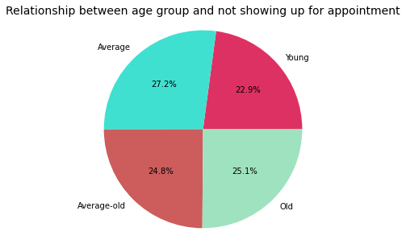

```python
#plotting the result in a pie chart to visualise the age distribution with respect to not showing up for appointment
plt.subplots(figsize=(8, 5))
color = ['#DE3163','#40E0D0', '#CD5C5C', '#9FE2BF']
label = ['Young', 'Average', 'Average-old', 'Old']
plt.pie(groupage1, labels=label, autopct='%1.1f%%', colors =color)
plt.axis('equal')
plt.title('Relationship between age group and not showing up for appointment', fontsize=14);
```

Since the values for each of the age group are similar, it seems that there is no significant correlation between age of patients and not showing up for an appointment.

## Conclusions

Limitations

This analysis do not explore the relationship between variables such as alcoholism, appointment day, handicap and showing up for an appointment.